# Posterior sampling with Markov chain Monte Carlo

Peter Ralph

9 November – Advanced Biological Statistics

# Hierarchical coins

## Motivating problem: more coins

## Motivating problem: more coins

Suppose now we have data from $n$ different coins from the same source. We don’t assume they have the *same* $\theta$, but don’t know what its distribution is, so try to *learn* it.

$$\begin{aligned}
Z_i &\sim \Binom(N_i, \theta_i) \\
\theta_i &\sim \Beta(\alpha, \beta) \\
\alpha &\sim \Unif(0, 100) \\
\beta &\sim \Unif(0, 100)
\end{aligned}$$

**Goal:** find the posterior distribution of $\alpha$, $\beta$.

## Binomial versus Beta-Binomial

For instance: if you were given datasets from one of these situations, how would you tell which situation it was generated from?

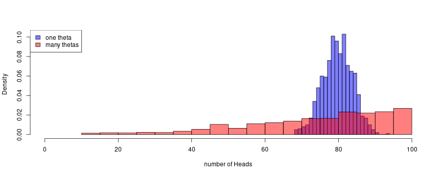

```r
ncoins <- 1000
nflips <- 100
theta1 <- rbeta(1,3,1)
binom_Z <- rbinom(ncoins, size=nflips, prob=theta1)
theta2 <- rbeta(ncoins,3,1)
bb_Z <- rbinom(ncoins, size=nflips, prob=theta2)
hist(binom_Z, breaks=30, col=adjustcolor("blue", 0.5), main='', xlim=c(0,nflips), freq=FALSE, xlab='number of Heads')
hist(bb_Z, breaks=30, col=adjustcolor("red", 0.5), add=TRUE, freq=FALSE)
legend("topleft", fill=adjustcolor(c('blue', 'red'), 0.5), legend=c('one theta', 'many thetas'))
```

**Problem:** Find the posterior distribution of $\alpha$ and $\beta$, given some data $(Z_1, N_1), \ldots, (Z_k, N_k)$, under the model:
$$\begin{aligned}
Z_i &\sim \Binom(N_i, \theta_i) \\
\theta_i &\sim \Beta(\alpha, \beta) \\
\alpha &\sim \Unif(0, 100) \\
\beta &\sim \Unif(0, 100) .
\end{aligned}$$

**Problem:** we don’t have a nice mathematical expression for the posterior distribution.

# MC Stan

## Stan

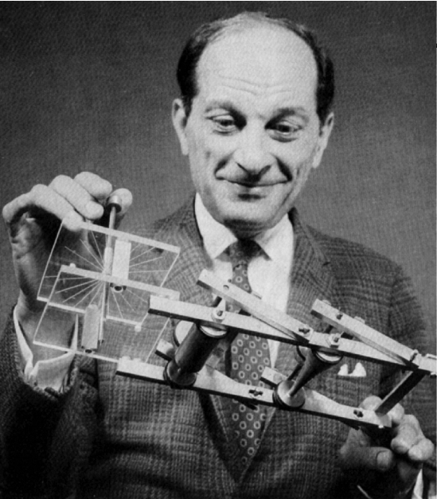

Stanislaw Ulam

## The skeletal Stan program

```
data {
    // stuff you input
}
transformed data {
    // stuff that's calculated from the data (just once, at the start)
}
parameters {
    // stuff you want to learn about
}
transformed parameters {
    // stuff that's calculated from the parameters (at every step)
}
model {
    // the action!
}
generated quantities {
    // stuff you want computed also along the way
}
```

# Markov Chain Monte Carlo

## When you can’t do the integrals: MCMC

**Goal:** Given:

- a model with parameters $\theta$,
- a prior distribution $p(\theta)$ on $\theta$, and
- data, $D$,

“find”/ask questions of the posterior distribution on $\theta$,

$$\begin{aligned}
p(\theta \given D) = \frac{ p(D \given \theta) p(\theta) }{ p(D) } .
\end{aligned}$$

**Problem:** usually we can’t write down an expression for this (because of the “$p(D)$”).

**Solution:** we’ll make up a way to *draw random samples* from it.

**Toy example:**

*(from beta-binomial coin example)*

Do we think that $\theta < 0.5$?

*(before:)*

```r
pbeta(0.5, post_a, post_b)
```

*(now:)*

```r
mean(rbeta(1e6, post_a, post_b) < 0.5)
```

## How? Markov chain Monte Carlo!

i.e., “random-walk-based stochastic integration”

## Overview of MCMC

Produces a random sequence of samples $\theta_1, \theta_2, \ldots, \theta_N$.

0. Begin somewhere (at $\theta_1$).

At each step, starting at $\theta_k$:

1. **Propose** a new location (nearby?): $\theta_k'$
2. Decide whether to **accept** it.
   - if so: set $\theta_{k+1} \leftarrow \theta_k'$
   - if not: set $\theta_{k+1} \leftarrow \theta_k$
3. Set $k \leftarrow k+1$; if $k=N$ then stop.

The magic comes from doing *proposals* and *acceptance* so that the $\theta$’s are samples from the distribution we want.

## Key concepts

- Rules are chosen so that $p(\theta \given D)$ is the *stationary* distribution (long-run average!) of the random walk (the “Markov chain”).
- The chain must *mix* fast enough so the distribution of visited states *converges* to $p(\theta \given D)$.
- Because of *autocorrelation*, $(\theta_1, \theta_2, \ldots, \theta_N)$ are not $N$ independent samples: they are roughly equivalent to $N_\text{eff} < N$ independent samples.
- For better *mixing*, acceptance probabilities should not be too high or too low.
- Starting *several chains* far apart can help diagnose failure to mix: Gelman’s $r$ quantifies how different they are.

## Let’s “walk around”:

In each group, have one *walker* directed by others:

0. Start somewhere at “random”, then repeat:
1. Pick a random $\{N,S,E,W\}$.
2. Take a step in that direction,
   - *unless* you’d run into a wall or a table.

*If online:* take a screenshot of your path after:

- 10 steps
- 50 steps

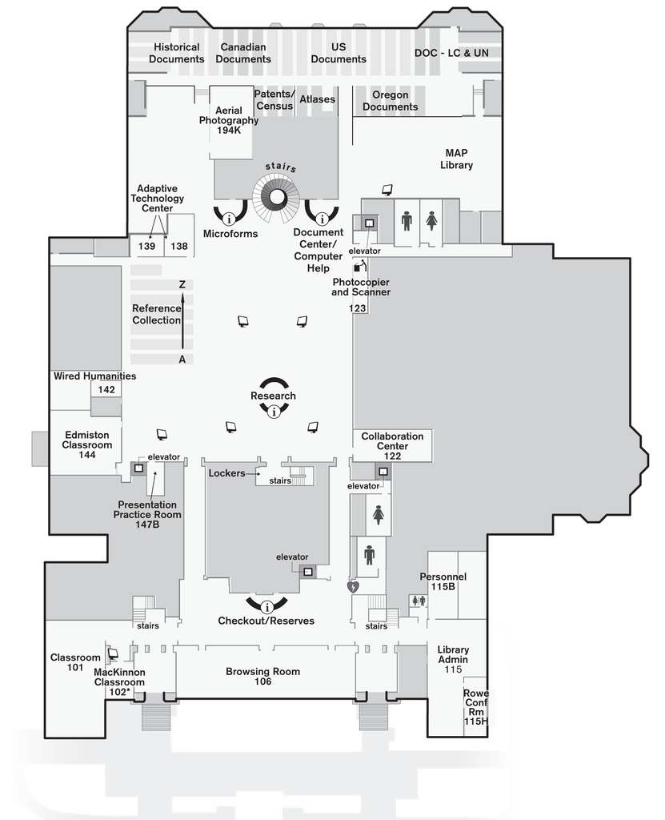

image of floor plan of Knight library

Imagine the heatmap of how much time your “walker” has spent in each place in the library.

**Question:** What distribution does this sample from?

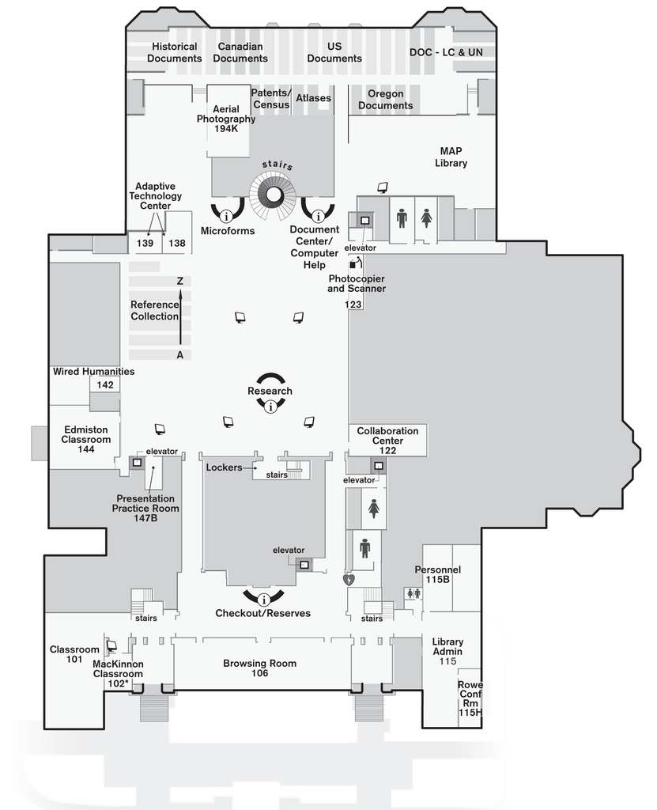

image of floor plan of Knight library

**Now:**

1. Pick a random $\{N,S,E,W\}$.
2. Take a $1+\Poisson(5)$ number of steps in that direction,
   - *unless* you’d run into a wall.

*If online:* again, take a screenshot of your path after:

- 10 steps
- 50 steps

Does it mix faster?

Would $1 + \Poisson(50)$ steps be better?

## How it works

What would *this* do?

Thanks to [*Metropolis-Hastings*](https://en.wikipedia.org/wiki/Metropolis%E2%80%93Hastings_algorithm), if “elevation” is $p(\theta \given D)$, then setting $p = p(\theta' \given D) / p(\theta \given D)$ makes the stationary distribution $p(\theta \given D)$.